# Agroecological performance of smallholder dairy cattle systems in the Peruvian Amazon - ScienceDirect

## [Agricultural Systems](https://www.sciencedirect.com/journal/agricultural-systems)

[Volume 223](https://www.sciencedirect.com/journal/agricultural-systems/vol/223/suppl/C), February 2025, 104199

# Agroecological performance of smallholder dairy cattle systems in the Peruvian Amazon

https://doi.org/10.1016/j.agsy.2024.104199[Get rights and content](https://s100.copyright.com/AppDispatchServlet?publisherName=ELS&contentID=S0308521X24003494&orderBeanReset=true)

Under a Creative Commons [license](http://creativecommons.org/licenses/by-nc/4.0/)

open access

## Highlights

- •

  The Tool for Agroecological Performance Evaluation was used on 22 smallholder farms in the Peruvian Amazon.
- •

  Silvopastoral systems are more agroecological than conventional systems, regardless of herd size.
- •

  There were only two correlations among the 10 Elements of Agroecology and the 11 SDG-linked indicators of the tool.
- •

  Four SDG-linked indicators showed a quadratic effect with the level of agroecological transition.
- •

  Agroecological practices may support both economic and social sustainability outcomes.

## Abstract

### CONTEXT

In Peru, silvopastoral systems have been included as a national measure to address deforestation and mitigate carbon emissions. Limited studies have assessed the sustainability of mixed livestock-crop systems using tools that address multiple Sustainable Development Goals (SDG).

### OBJECTIVE

We assessed the sustainability of smallholder dairy farms in the Peruvian Amazon as affected by system type (silvopastoral or conventional) and herd size (medium or large) using the Tool for Agroecological Performance Evaluation (TAPE). Furthermore, we explored the linkages among TAPE indicators including the 10 Elements of Agroecology (EA), an overall evaluation scale (Characterization of Agroecological Transition; CAET), and 11 SDG-linked Core Criteria of Performance (CCP).

### METHODS

Twenty-two farmers of the San Martin region were surveyed. Data were subjected to analysis of variance, Pearson correlations, and fitted to linear and quadratic functions.

### RESULTS AND CONCLUSIONS

Silvopastoral systems showed a greater agroecological transition than conventional systems (69.0 vs. 60.2; CAET mean) regardless of herd size.

Results suggested that EA and CCP were essentially independent of each other if linearity was assumed. However, concave quadratic relationships were detected between the CAET and 4 CCP: *Farm Income*, *Agricultural Net Income, Dietary Diversity,* and *Women's Empowerment*. For these CCP, depressed values for farms with intermediate CAET (60 to 69) suggested that they neither reap the full benefits of agroecological practices found mainly in silvopastoral farms (CAET >70) nor the full benefits of conventional practices (CAET <60)*.*

### SIGNIFICANCE

The implementation of agroecological practices in smallholder systems may support positive economic and social sustainability outcomes.

## Graphical abstract

[figure not shown]

## Keywords

Sustainability

Silvopasture

Smallholder livestock

Tropics

Agroecology

## 1. Introduction

There is an ongoing debate on the role of livestock in the sustainable development of agriculture in Latin America. Livestock have been associated with deforestation (Wassenaar et al., 2007) and substantial greenhouse gas emissions (O'Mara, 2011), but they are critical to the livelihood of many poor smallholders (Herrero et al., 2009), and they provide ecosystem services for society at large scale (Sanderson et al., 2013; Alders et al., 2021). Sustainable intensification of agriculture can be viewed as the process through which productivity is enhanced without causing adverse environmental impacts or requiring the conversion of additional land (Pretty and Bharucha, 2014). Angelsen and Kaimowitz (2001) argued that the economic advantages derived from sustainable intensification might disincentivize deforestation or land acquisition for crop production. Similarly, Garcia et al. (2017) suggested that sustainable intensification of livestock in the Amazon could halt deforestation while creating positive social and environmental outcomes. Nevertheless, others have warned that the profitability of intensified systems could have the opposite effect, leading to higher conversion of forests into pasture lands (Kaimowitz and Angelsen, 2008). In Peru, cattle ranching is the second most important driver of deforestation after crop production (Vasquez Jara, 2019). Deforestation in the Peruvian Amazon has been substantial and continues to date. At the national level, the Peruvian Government has incorporated silvopastoral systems in its Nationally Determined Contribution to the Paris Agreement and has committed to increase land under silvopastoral practices by 119,000 ha by 2030 as a measure to reduce carbon emissions (Gobierno del Peru, 2020).

Silvopastoral systems purposely combine trees, pasture, and livestock. Thus, they are diversified and multifunctional. In Latin America, the implementation of silvopastoral systems has been limited due to technical, economic, and knowledge gaps (Arango et al., 2020). However, these systems have been purported to provide economic resilience to producers through diversification of income (milk, beef, fruits, timber) and environmental benefits to society, such as enhancing carbon sequestration and enriching biodiversity (Jose and Dollinger, 2019). Recently, Picasso and Pizarro (2024) indicated that benefits and tradeoffs of silvopastoral systems should be assessed in relation to the “starting point” (primary forest versus degraded pastures). Noting considerable variability in methodology, specificity and assumption, Schader et al. (2014) concluded that a universal tool to assess agricultural and food systems sustainability does not exist. The hesitation of farmers to rely on sustainability assessment outcomes for decision-making has led authors to suggest that discussion, reflection, and learning should be considered as the primary outcomes of their implementation (De Olde et al., 2016). Thus, Wattiaux (2023) suggested using the Sustainable Development Goals (SDG) as a nationally vetted framework to identify context-specific farm-level metrics to explore synergies and tradeoffs while supporting agreed-upon global targets. In 2018, the Food and Agricultural Organization (FAO) of the United Nations released the Tool for Agroecological Performance Evaluation (TAPE) to assess agroecological transitions of agricultural production systems at the farm level, based on the 10 Elements of Agroecology (EA). TAPE is unique because it includes a set of Core Criteria of Performance (CCP) indicators that have been linked to 7 SDG concerned with a) human health and nutrition, b) economic performance, c) environmental impact, d) society and culture, and e) governance (FAO, 2019; Mottet et al., 2020).

In this study, we assessed the sustainability at the farm scale of smallholder farms with milk or cheese production as a primary economic activity in the San Martin region, which has one of the highest deforestation rates in the nation (515,364 ha between 2001 and 2023; MINAM, 2024). Data collected with TAPE was used to compare agroecological performance and test the hypothesis that farms classified as silvopastoral ranked higher than conventional farms on the TAPE's characterization of agroecological transition (CAET) scale regardless of herd size. A second objective was to explore the degree to which the EA were linked to each other and to the CAET. A third objective was to test the hypothesis that the CCP (i.e., SDG-linked indicators) were greater for farms classified as silvopastoral than conventional regardless of herd size. Finally, our fourth objective was to explore the data for evidence of linkages among agroecological practices and SDG-linked CCP indicators of TAPE. While relationships between single criteria are often studied, broader scopes of multicriteria analysis are still missing despite being promoted as methodological advances.

## 2. Materials and methods

### 2.1. Study design

The Institutional Review Board of Universidad Nacional Agraria La Molina (Lima, Peru) approved the procedures used in this study.

#### 2.1.1. Study site and farm selection

Silvopastoral systems are not new in the Peruvian Amazon, where we have characterized livestock systems (Pizarro et al., 2020; Navarro et al., 2023). Our study site was Cuñumbuqui, which is the district specialized in the production of milk and cheese in the San Martin region. Cuñumbuqui has an area of 193,00 km<sup>2</sup> and a population of 3301 inhabitants (INEI, 2017). The average altitude is 200 m above sea level with an average temperature, relative humidity, and monthly rainfall of 27.5 °C, 73.5 %, and 45 mm, respectively (SENAMHI, 2023). Eligible farms were selected from a Universidad Nacional Agraria La Molina database populated for a companion study using farmers' self-reported data (*n* = 71). Self-reported tree cover of grazing area was either 10 % or less (*n* = 52), 11–30 % (*n* = 17) or 31–50 % (*n* = 2). In this study, farms with 10 % or less tree cover of grazing area were classified as conventional (CON; n = 52), and those with 11 % or more were classified as silvopastoral (SPS, *n* = 19). In addition, farms were categorized by herd size, because of environmental concerns related to livestock. Using the INEI (2012) agricultural census categorization, herd size was classified as small (10 or less heads of cattle; *n* = 9), medium (MED; 11 to 49 heads of cattle; *n* = 19), or large (LRG; 50 or more heads of cattle, *n* = 43). Small herd size farms were not considered in our study because of limited sampling capacity. For this study, participants were identified with a purposive sampling method (Vogt and Johnson, 2016). Due to limited road access and time constraints for data collection, farmers from communities along the main paved road were invited in person to participate. Thus, farms in the study comprised 11 SPS farms (6 MED and 5 LRG) and 11 CON farms (5 MED and 6 LRG). These 22 farms were from 7 populated centers of Cuñumbuqui district: Cuñumbuqui (n = 1), Estero del Rio Mayo (n = 1), Difuntillo (*n* = 2), Saucal (n = 2), San Fernando (n = 9), San Francisco (*n* = 5), and San Francisco del Rio Mayo (n = 2).

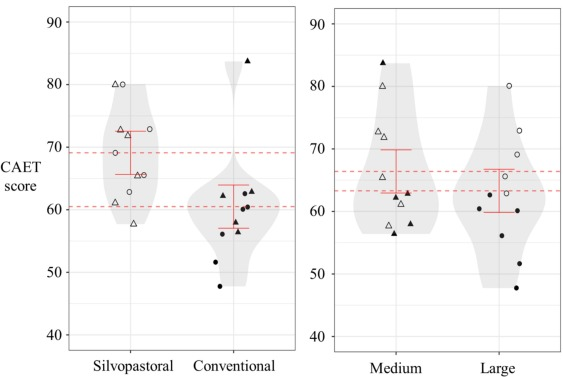

1. [Download: Download high-res image (147KB)](https://ars.els-cdn.com/content/image/1-s2.0-S0308521X24003494-gr1_lrg.jpg)
2. [Download: Download full-size image](https://ars.els-cdn.com/content/image/1-s2.0-S0308521X24003494-gr1.jpg)

Fig. 1. CAET scores for farms classified as silvopastoral (white symbols) or conventional (black symbols) system and as medium (triangles) or large (circles) herd size. Dashed lines indicate model-implied means, and error bars show the standard error of the mean.

#### 2.1.2. TAPE and its implementation

The historical development of TAPE and its methodological details have been published by Mottet et al. (2020). Guidelines for application are available at FAO (2019) and training for enumerators is available at FAO (2021). Briefly, TAPE consists of 4 separate steps. Step 0 involves the description of the systems and their context through primary and secondary sources of information. This step identifies the background factors that are enabling the system to exist in its current state. Step 1 and Step 2 consist of a household (on-farm) survey data collection instrument. Step 1 focuses on the 10 EA: *Diversity, Synergies, Efficiency, Recycling, Resilience, Culture & Food Traditions, Co-creation & Sharing of Knowledge, Human & Social Values, Circular & Solidarity Economy,* and *Responsible Governance*. Each element comprises 3 to 4 indices, which are scored on a scale of 0 (undesirable) to 4 (desirable; Appendix Table A1). For each element, the sum of its indices is expressed as a percentage of the maximum score (either 12 or 16). Then, the CAET is calculated as the average of the percentage scores of the 10 EA. In addition, we followed El Mujtar et al. (2023), who proposed to calculate a Farm-CAET and a Community-CAET, each based on five of the 10 EA, with the former reflecting farm practices and the latter describing a set of broader factors that operate mainly at the community level (see Appendix Table A1). Step 2 of TAPE includes the following SDG-linked CCP: *Secure Land Tenure* (SDG 1, 2, 5), *Productivity* (SDG 2), *Farm Income* (SDG 1, 2, 10), *Pesticide Exposure* (SDG 3), *Dietary Diversity* (SDG 2), *Women's Empowerment* (SDG 2, 5), *Youth Employment* (SDG 8), *Agricultural Biodiversity* (SDG 2, 15), and *Soil Health* (SDG 1, 15). *Added Value* (SDG 10) was not considered in our study because participants reported no subsidies and no income from rent, which are the two items differentiating it from *Farm Income*. However, due to the nature of our study, two CCP were added: *Income from Dairy* and *Agricultural Net Income*. Each CCP, including the ones added, has its own method of assessment, the description of which can be found in FAO (2019) and Appendix Table A2. After the research team analyzes, interprets, and summarizes the data, Step 3 of TAPE is implemented as a community-based participatory process, allowing for validation of the results through meetings, workshops, reports, and/or peer-reviewed publications.

In this study, Step 0 data were from a variety of sources including literature (Sánchez-Huaripata and Arévalo-Arévalo, 2023), official records, and the expert knowledge of the research team who had worked with the community on related projects. Steps 1 and 2 data were collected between January and June 2022. Surveys were completed by hand using printed forms. Each survey was conducted with the head of household as the survey participants, who were men in most cases (*n* = 21). They answered all survey items, except those related to *Women's Empowerment*, which were expected to be addressed by women alone. Surveys were completed in one visit that lasted 2.5 to 3 h. However, *Soil Health* assessment of Step 2 was completed during a separate visit during which soil samples were collected for a companion study (Salazar et al., 2024). For Step 3, the research team conducted a half-day workshop in Cuñumbuqui in October 2023 to collect data related to the usefulness of the tool, and to stimulate a discussion on potential beneficial collective actions. These data are not part of this publication.

### 2.2. Calculation and statistical analysis

All the statistical procedures were conducted with R version 4.1.2 (R Core Team, 2021). For all analyses, an effect was reported as significant (*P* ≤ 0.05) or as a trend (0.05 < *P* ≤ 0.10). To test our hypothesis that SPS farms had greater EA and CAET scores (objective 1) and greater SDG-linked CCP (objective 3) than the CON farms regardless of herd size, we fitted the scores of each EA, the CAET score, the Farm-CAET score, the Community-CAET score, and the 11 CCP variables to the following model:

Y<sub>ijk</sub> = μ + Sys<sub>i</sub> + Siz<sub>j</sub> + (Sys<sub>i</sub> x Siz<sub>j</sub>) + e<sub>ijk</sub>,

where Y<sub>ijk</sub> is the response variable, μ is the overall mean, Sys<sub>i</sub> is the fixed effect of the system, Siz<sub>j</sub> is the fixed effect of size, (Sys<sub>i</sub> x Siz<sub>j</sub>) is the system by size interaction, and e<sub>ijk</sub> is the random residual error. Additionally, a paired *t*-test was performed between the Farm-CAET and the Community-CAET to test the hypothesis that the CAET might be improved with the adoption of agroecological practices that operate mainly at the farm level rather than at the community level. Visual inspection of the quantile-quantile (QQ) plots indicated skewness in the data distribution. However, we validated the adequateness of our statistics by generating residual plots and confirming the randomness of the residuals. Potential outliers were identified using scatter plots. After running the model with and without the potential outliers, the statistical inferences remained unchanged. Thus, all observations were included in this analysis.

Pearson correlations were used to test the hypothesis that the EA were related to each other and to the CAET (objective 2). For the 10 correlations between each EA and the CAET, an adjusted CAET (CAET<sub>a</sub>) was calculated without the score of the EA to which it was correlated to avoid autocorrelation. When a significance was detected, the relationship was studied further by correlating each of the indices (*n* = 3 or 4) of the EA to the CAET using Kendall rank correlation coefficient (τ) due to the ordinal nature of the variables. Significant Kendall correlations were used to identify the likely driver of the associations and thus a possible causal linkage between the EA and the CAET.

To meet objective 4, we used Pearson correlations between the EA and the CCP and regressed each CCP on the CAET score to test both linear and quadratic effects. When significance was detected, we analyzed the variables involved in calculating the indicators by computing descriptive statistics and relying on an analysis of the coefficient of variation (as a dispersion measure) to identify the possible drivers of the relationship.

## 3. Results

### 3.1. Description of local context

Research in the Amazon region has shown that grasses under SPS had a similar total forage accumulation, but greater nutritive value compared with open pastures (Do Nascimento et al., 2019; Gomes et al., 2022). In Cuñumbuqui, the land has a sloping topography with paddocks and property lines delimited with wire fences or trees used as live fences. Sánchez-Huaripata and Arévalo-Arévalo (2023) reported average farm size of 30 ha and 22 heads of dual-purpose cattle. Most of the cattle were crossbred (Gyr*Holstein and Gyr*Brown Swiss) used for both milk and beef production. Most farmers do the milking by hand once a day and milk production on average was 4.5 L/cow/day. Feeding was based mainly on cultivated pastures (*Brachiaria brizantha*), with limited management practices. Supplementation included cut-&-carry of forages such as elephant grass (*Pennisetum purpureum*). Milk production was used partially for household consumption but mostly for sale. The milk was collected daily by a local processor or by intermediary haulers who resell it to processing plants. Eventually, dairy products are sold in outdoor and street markets or in retail stores in Tarapoto, the largest city in the region (population 76,122; INEI, 2017). Based on the 22 observations of our study, we observed substantially more men than women living in the household (mean ± SEM; 1.6 ± 0.2 vs. 1.0 ± 0.2). Most of the men (1.5 ± 0.2) were responsible for the farm labor compared to women (0.3 ± 0.1). Productive land (48.4 ± 6.8 ha) was primarily pasture (30.3 ± 4.2, ranging from 7 to 80 ha) grazed by cattle and some crops for consumption by humans or small livestock. The herd size averaged 57 ± 7 heads, ranging from 22 to 170 heads. All households commercialized their products, but 5 of the 22 households reported that self-consumption was equal to or greater than sale as the intended destination of their agricultural production. These characteristics are shown by system type in Appendix Table A3.

### 3.2. Agroecological transition

Table 1. Effect of system type (SYS; silvopastoral vs. conventional) and herd size (SIZE; Medium vs. Large) on the mean score of the 10 Elements of Agroecology (EA) and the Characterization of Agroecological Transition (CAET) of smallholder livestock farms in the Peruvian Amazon (*n* = 22).

| Item | Silvopastoral system Medium | Silvopastoral system Large | Conventional system Medium | Conventional system Large | SEM | *P*-value SYS | *P*-value SIZE | *P*-value SYS*SIZE |
| --- | --- | --- | --- | --- | --- | --- | --- | --- |
| Diversity | 55.2<sup>b</sup> | 67.5<sup>a</sup> | 65.0<sup>ab</sup> | 56.2<sup>b</sup> | 2.90 | 0.90 | 0.77 | 0.09 |
| Synergies | 90.6 <sup>a</sup> | 97.5<sup>a</sup> | 92.5<sup>a</sup> | 76.0<sup>b</sup> | 1.68 | < 0.01 | 0.11 | < 0.01 |
| Efficiency | 60.4 | 61.2 | 58.8 | 49.0 | 2.49 | 0.18 | 0.32 | 0.30 |
| Recycling | 51.0 | 33.8 | 33.8 | 26.0 | 3.16 | 0.04 | 0.06 | 0.46 |
| Resilience | 60.7 | 73.1 | 47.5 | 57.8 | 2.98 | 0.04 | 0.07 | 0.86 |
| Culture & Food Traditions | 87.5 | 86.7 | 90.0 | 84.7 | 2.46 | 1.00 | 0.54 | 0.66 |
| Co-Creation & Sharing of Knowledge | 51.4 | 31.7 | 46.7 | 20.8 | 4.30 | 0.26 | 0.02 | 0.73 |
| Human & Social Values | 68.8<sup>ab</sup> | 81.2<sup>a</sup> | 73.8<sup>ab</sup> | 56.2<sup>b</sup> | 4.24 | 0.24 | 0.77 | 0.09 |
| Circular & Solidarity Economy | 75.0 | 85.0 | 65.0 | 63.9 | 3.39 | 0.04 | 0.52 | 0.42 |
| Responsible Governance | 80.6 | 83.3 | 73.3 | 73.6 | 4.22 | 0.34 | 0.86 | 0.88 |
| CAET<sup>1</sup> | 68.1 | 70.1 | 64.6 | 56.4 | 1.73 | 0.02 | 0.38 | 0.16 |
| Farm-CAET<sup>2</sup> | 63.6 | 66.6 | 59.5 | 53.0 | 1.59 | 0.01 | 0.59 | 0.15 |
| Community-CAET<sup>2</sup> | 72.6 | 73.6 | 69.8 | 59.9 | 2.71 | 0.13 | 0.42 | 0.33 |

<sup>a,b</sup>Means not sharing a common superscript differ (*P* < 0.05; emmeans pairwise comparison for variables exhibiting tendency or significant SYS*SIZE interaction).

**1**

Calculated as the average score of the 10 EA.

**2**

Farm-CAET calculated as the average score of Diversity, Synergies, Efficiency, Recycling, and Resilience and Community-CAET calculated as the average score of Culture & Food Tradition, Co-Creation & Sharing of Knowledge, Human & Social Values, Circular & Solidarity Economy, and Responsible Governance (as outlined in El Mujtar et al., 2023).

To satisfy our second objective, we reported the correlations between the EA and the CAET in Fig. 2. *Synergies* (*r* = 0.59), *Co-Creation & Sharing of Knowledge* (*r* = 0.55), *Circular & Solidarity Economy* (*r* = 0.60), and *Responsible Governance* (r = 0.60) displayed moderate correlations with the CAET (all *P* < 0.01). Significant Kendall correlations between CAET and EA indices (listed in Appendix Table A1) allowed us to gain an insight into the nature and possible causation of these relationships. First, the correlation between *Synergies* and the CAET was likely due to the higher crop-livestock-aquaculture integration leading to lesser dependence for externally purchased inputs (τ = 0.52*; P* < 0.01). Farmers whose farms had a greater CAET score had cattle exclusively grazed, and manure was the only fertilizer for pastures. The integration of the trees with the other farm components was notably not the main driver of this correlation. Second, the correlation between *Co-Creation & Sharing of Knowledge* and the CAET existed probably because farmers managing farms with superior CAET reported greater awareness of the agroecological principles and eagerness to apply them on their farms (τ = 0.44*; P* = 0.01). Third, the correlation between *Circular & Solidarity Economy* and the CAET was due mainly to the existence of a local food system in which the community is almost entirely self-sufficient for agricultural and food production, with few food supplies and inputs purchased outside the community (τ = 0.55*; P* < 0.01). Fourth, the correlation between *Responsible Governance* and the CAET was likely explained by the existence of more than one farmer's organization for market access with equal access to men and women (τ = 0.49*; P* < 0.01). Producers' empowerment (self-efficacy to improve livelihood) and producers' participation in the governance of the land and natural resources were the lesser indices driving this correlation.

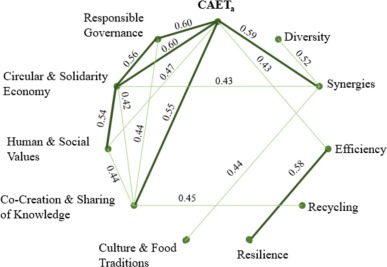

1. [Download: Download high-res image (117KB)](https://ars.els-cdn.com/content/image/1-s2.0-S0308521X24003494-gr2_lrg.jpg)
2. [Download: Download full-size image](https://ars.els-cdn.com/content/image/1-s2.0-S0308521X24003494-gr2.jpg)

Fig. 2. Pearson correlations among the 10 Elements of Agroecology (EA) and between them and CAET<sub>a</sub> which is the CAET calculated without the score of EA to which it was correlated (*n* = 22). Thick lines indicate *P* < 0.01, and thin lines indicate 0.01 *≤ P* < 0.05.

Fig. 2 shows also the presence of moderate but significant (all *P* < 0.01) correlations among the 10 EA, specifically between *Efficiency* and *Resilience* (*r* = 0.58), *Human & Social Values* and *Circular & Solidarity Economy* (*r* = 0.54), and *Circular & Solidarity Economy* and *Responsible Governance* (*r* = 0.56). The correlation between *Efficiency* and *Resilience* was likely due to the fact that the lower usage of chemical pesticides on the more efficient farms was associated with a higher stability of income and production from year to year of the resilient farms (τ = 0.64*; P* < 0.01). Furthermore, farmers who met their household needs (one of the *Efficiency* indices) reported the existence of social mechanisms to reduce vulnerability (one of the *Resilience* indices; τ = 0.42*; P* = 0.03). The correlation between *Human & Social Values* and *Circular & Solidarity Economy* was likely explained by an association between a higher empowerment of women in decision-making and access to resources and the existence of well-established and operational networks with equal women participation (τ = 0.43*; P* = 0.03). Finally, the correlation between *Circular & Solidarity Economy* and *Responsible Governance* was likely explained because when the survey participants reported that their community was almost entirely self-sufficient for agricultural and food production they also reported that more than one farmer's organization existed in their community providing market access and other services (τ = 0.53*; P* < 0.01).

### 3.3. Core criteria of performance

To satisfy our third objective, Table 2 reports the effect of system type, herd size, and their interaction on the CCP. All farmers reported having legal and secured recognition of their lands with their names listed as owners. They reported a secure ability to access lands and rights to sell, bequeath, and inherit lands. *Youth Employment* tended (*P* = 0.06) for greater scores on the farms with MED than LRG herd size in the SPS system (50 vs. 37.5 points) but lower scores on the farms with MED than LRG herd size in the CON system (37.5 vs 75 points). *Productivity* score tended to be twice as large for the SPS than the CON farms (3249 vs. 1545 soles/ha/year, *P* = 0.06), and *Women's Empowerment* score tended to be lower on the farms with MED than LRG herd size (57.1 vs. 64.5 points, *P* = 0.07).

Table 2. Effect of system type (SYS; Silvopastoral vs. Conventional) and herd size (SIZE; Medium vs. Large) on Core Criteria of Performance of smallholder livestock farms in the Peruvian Amazon (*n* = 22).

| Core Criteria of Performance | Silvopastoral system Medium | Silvopastoral system Large | Conventional system Medium | Conventional system Large | SEM | *P*-value SYS | *P*-value SIZE | *P*-value SYS*SIZE |
| --- | --- | --- | --- | --- | --- | --- | --- | --- |
| Secured Land Tenure<sup>1</sup> | 100 | 100 | 100 | 100 | 0.0 | na<sup>3</sup> | na | na |
| Productivity (soles/ha/year) | 2739 | 3862 | 1720 | 1399 | 433 | 0.06 | 0.65 | 0.42 |
| Farm Income (soles/year) | 33,678 | 15,562 | 23,429 | 27,516 | 7197 | 0.95 | 0.63 | 0.45 |
| Income from Dairy (soles/year)<sup>2</sup> | 33,583 | 59,152 | 33,600 | 46,048 | 7806 | 0.68 | 0.24 | 0.68 |
| Agricultural Net Income (soles/worker/year)<sup>2</sup> | 16,557 | 9732 | 16,967 | 14,605 | 3762 | 0.73 | 0.55 | 0.77 |
| Pesticide Exposure (soles/ha/year) | 137 | 92.5 | 72.0 | 88.0 | 29.5 | 0.56 | 0.81 | 0.62 |
| Dietary Diversity<sup>1</sup> | 7.2 | 4.0 | 5.8 | 6.50 | 0.59 | 0.65 | 0.32 | 0.11 |
| Women's Empowerment<sup>1</sup> | 58.6 | 64.0 | 54.7 | 64.9 | 2.03 | 0.72 | 0.07 | 0.56 |
| Youth Employment<sup>1</sup> | 50.0<sup>ab</sup> | 37.5<sup>b</sup> | 37.5<sup>b</sup> | 75.0<sup>a</sup> | 4.30 | 0.24 | 0.24 | 0.06 |
| Agricultural Biodiversity<sup>1</sup> | 40.0 | 39.5 | 39.6 | 30.9 | 1.78 | 0.22 | 0.21 | 0.27 |
| Soil Health<sup>1</sup> | 4.12 | 4.28 | 4.10 | 4.02 | 0.07 | 0.31 | 0.77 | 0.37 |

<sup>a,b</sup>Means not sharing a common superscript differ (*P* < 0.05; emmeans pairwise comparison for variables exhibiting tendency or significant SYS*SIZE interaction).

**1**

Core Criteria of Performance with a unitless score but points ranging from either 1 to 5 (Soil Health), 1 to 10 (Dietary Diversity), or 1 to 100 (Secure Land tenure, Women's Empowerment, Youth Employment, and Agricultural Biodiversity).

**2**

Specific indicators included to this study.

**3**

na = not applicable.

### 3.4. Linkages between agroecological practices and core criteria of performance

To satisfy our fourth objective, we explored all 110 possible correlations between the EA and the CCP of this study and fitted linear and quadratic relationships between the CAET and the 10 CCP exhibiting variability (Table 2). Only two correlations were significant (*P* < 0.05). The CCP *Productivity* (soles/ha/year) was correlated with both the EA *Circular & Solidarity Economy* (*r* = 0.53) and with the EA *Responsible Governance* (*r* = 0.47). Our analysis of the Kendall correlations in search of possible causal relationship suggested that the existence of a local food system was the index within *Circular & Solidarity Economy* that tended to be associated with *Productivity* (τ = 0.29*; P = 0.08*) and farmer's participation in the governance of land and natural resources was the index within *Responsible Governance* that tended to be associated with *Productivity* (τ = 0.30*; P = 0.10*).

Table 3 shows the 4 CCP that displayed linear and quadratic relationships with the CAET either significantly: *Farm Income* and *Agricultural Net Income* (indicators of Economic dimension of sustainability) or as a tendency: *Woman's Empowerment* (an indicator of Society & Culture dimension of sustainability) and *Dietary Diversity* (an indicator of Health & Nutrition dimension of sustainability). To consider the possible influence of the CON farm with the highest CAET score (Fig. 1, Fig. 3), we ran the model excluding that farm. Removing that data point resulted in no change in the level of significance of *Farm Income* and *Agricultural Net Income*; however, the quadratic effect for Women's Empowerment became significant (*P* = 0.01) and the quadratic effect for *Dietary Diversity* became non-significant (*P* = 0.25). Fig. 3 showed a general pattern based on all data points (*n* = 22) by which farms with intermediate CAET, in the range of 60 and 70, had lower performance than those with lower CAET (i.e., CAET <60) or those with higher CAET (i.e., CAET >70). Fig. 3 also reveals that farms could be grouped into 3 categories based on the CAET: low (mainly CON farms with CAET <60, intermediate (a mix of CON and SPS farms with 60 ≤ CAET ≤70), and high (SPS farms with CAET >70). An examination of the variation (coefficient of variation) in the variables used in the calculation of these CCP indicators led to the following insights. In the case of *Farm income* (Total annual gross income – total expenses + subsidies), the CV of the total expenses of the farms with intermediate CAET was substantially greater (134 %) compared to the farms with low CAET (63 %) or high CAET (34 %). In the case of *Agricultural Net Income*, farms with intermediate CAET had substantially more workers (2.10 ± 0.66) than farms with low CAET (1.67 ± 0.68) or high CAET (1.83 ± 0.75). In addition, farms with intermediate CAET had the lowest *Agricultural Net Income* (12,800 ± 20,295 soles/worker/year) compared to farms with low CAET (33,217 ± 33,158 soles/worker/year) or high CAET (40,300 ± 41,305 soles/worker/year). Following a similar analysis to explore the concave relationship between *Women's Empowerment* and the CAET, we looked for similar patterns separately in each of the domains used to calculate this indicator: Productive decision, Access to and decision-making power about productive resources, Control over the use of income, Leadership in the community, and Time use. Even though there was not a clear pattern, farms with intermediate CAET had the lowest values for women's productive decision (0.72 ± 0.12) compared to farms with low CAET scores (0.73 ± 0.37) or high CAET scores (0.77 ± 0.07). Similarly, farms with intermediate CAET had the lowest values for women's leadership in the community (0.07 ± 0.09) compared to farms with low CAET (0.08 ± 0.11) or high CAET (0.12 ± 0.14). The relationship between *Dietary Diversity* and the CAET was not explored further because of the influence of a single farm on statistical inference.

Table 3. Core criteria of performance related to CAET score<sup>1</sup>.

| Core Criteria of Performance | Intercept | SE<sup>2</sup> | Linear Coefficient | Linear SE | Linear *P* | Quadratic Coefficient | Quadratic SE | Quadratic *P* |
| --- | --- | --- | --- | --- | --- | --- | --- | --- |
| Farm Income (soles/year) | 632,312 | 289,354 | −18,653 | 8786 | 0.05 | 141 | 65.8 | 0.05 |
| Agricultural Net Income (soles/worker/year) | 376,315 | 140,676 | −11,322 | 4272 | 0.02 | 86.9 | 32.0 | 0.01 |
| Dietary Diversity<sup>3</sup> | 49.1 | 25.3 | −1.36 | 0.77 | 0.09 | 0.01 | 0.01 | 0.09 |
| Women's Empowerment<sup>3</sup> | 221 | 86.6 | −4.7 | 2.63 | 0.09 | 0.03 | 0.02 | 0.10 |

**1**

There was no tendency (*P* < 0.10) or significant (*P* < 0.05) relationship between the CAET and the following Core Criteria of Performance: Secure Land Tenure, Productivity, Income from Dairy, Pesticide Exposure, Youth Employment, Agricultural Biodiversity, and Soil Health.

**2**

Standard error of the estimate.

**3**

Core Criteria of Performance scores with a unitless score but points ranging from either 1 to 10 (Dietary Diversity) or 1 to 100 (Women's Empowerment).

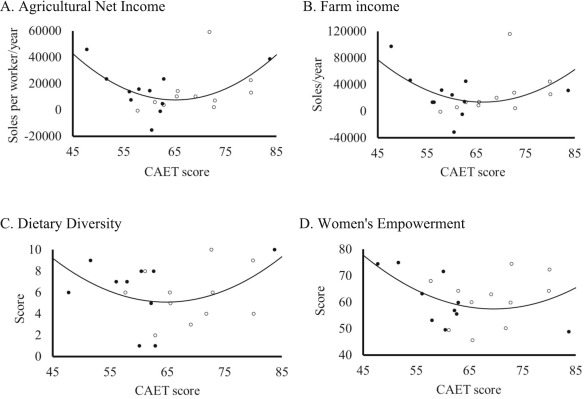

1. [Download: Download high-res image (203KB)](https://ars.els-cdn.com/content/image/1-s2.0-S0308521X24003494-gr3_lrg.jpg)
2. [Download: Download full-size image](https://ars.els-cdn.com/content/image/1-s2.0-S0308521X24003494-gr3.jpg)

Fig. 3. Core criteria of performance that tended or were significantly related to CAET score (*n* = 22); For each panel, the solid line represents the predicted values based on quadratic equation. Each data point is a farm (n = 22). Black and white symbols represent conventional and silvopastoral farms, respectively.

## 4. Discussion

### 4.1. CAET score typology

There is a large variation in the SPS practices in different regions of the Peruvian Amazon (Pizarro et al., 2020; Fuentes et al., 2022). However, our findings suggested that enhancing farm-level management practices, such as *Recycling* (which scored the lowest at 36), as a possible priority to improve the agroecological performance of the farms of this study. Indices that explained the low score of this element included the limited recycling of farm residues and by-products, the lack of equipment for water harvesting or saving (e.g., water tanks), and the limited use and production of renewable energy (e.g., solar energy). The second lowest EA was *Co-Creation & Sharing of Knowledge*. In this case, the low score was due to farmers reporting a lack of platforms for the creation and transfer of knowledge and their low participation in farmers' organizations. Although these findings were obtained with a limited sample size and farms located near the main paved road, our results established a baseline assessment. Future research should be extended to a larger and more diversified farms to allow for the delineation of Amazon farm typologies based on the EA and the CCP as measured in TAPE.

### 4.2. Linkages between Agroecological practices and the SDG-linked CCP

The assessment metrics of TAPE align with both sustainable agriculture (i.e., the EA of Step 1) and global targets built in the SDG (i.e., SDG-linked CCP of Step 2). Whether a greater score for EA (viewed as the system's attributes) was associated with a greater CCP (viewed as the system's outcomes) was one of the motivations for conducting this study. For the livestock systems studied here, we found a limited number of correlations between the EA and the CCP. The nature of the positive correlations between *Productivity* and *Circular & Solidarity Economy*, and between *Productivity* and *Responsible Governance* should be studied further. These correlations may be unique to this study but suggested that either *Productivity* is important for creating an environment enabling the agroecological transition, or in reverse, that *Responsible Governance* and *Circular & Solidarity Economy* are important contributors to *Productivity*. Nevertheless, the paucity of correlations between the EA and the CCP suggested that they are essentially independent of each other (if linearity is to be assumed).

Our study also revealed concave quadratic relationships for 2 indicators of economic performance: *Farm Income* (soles/year) and *Agricultural Net Income* (soles/worker/year; Table 3 and Fig. 3). These results are in general agreement with Lucantoni et al. (2023) who reported that a series of indicators of economic performance exhibited lower values for farms with intermediate CAET than for farms with lower or higher CAET. The authors suggested that the depressed intermediate score reflected a period during which a farmer learned to master agroecological practices. However, this interpretation of results assumed that agroecological transition is a stepwise process: Farmers are testing and adopting (or rejecting) new management practices and technologies over time. Alternatively, for farmers who are averse to changes, the agroecological transition (i.e., CAET score of their operation) may reflect a long-term structural characteristic of a farm. Regardless of the time scale, our data suggested that farms with intermediate CAET (i.e., between 60 and 70) were not getting the full benefits from applying agroecological practices (as observed on farms with high CAET), nor the full economic benefits from greater reliance on external inputs (as observed for conventional farms with low CAET). Our analysis of the variables used to calculate *Farm income* (soles/year) suggested that the reason for which values were depressed for farms with intermediate CAET scores was because of a greater level of expenses as opposed to a lesser revenue from the sale of milk and cheese (data not shown). Similarly, an analysis of the variables used to calculate *Agricultural Net Income* (soles/worker/year) indicated that the depressed values for farms with intermediate CAET score was explained by the combined effects of a reduced agricultural net income (i.e., the numerator of this indicator) and greater number of workers on the farms (i.e., the denominator of this indicator). Namely, in this study, *Agricultural Net Income* averaged 33,217, 12,800 and 40,300 soles for low (CAET <60), intermediate (60 ≤ CAET ≤70), and high (CAET >70) CAET farms, whereas the number of workers in the same three CAET categories averaged 1.7, 2.1, and 1.8, respectively. These findings suggested that household composition might play a role in this indicator. Most of the participating farms in our survey relied almost exclusively on family labor and therefore available labor may vary over time with the age and stage of life of each household member. In this study, the average age of the head of household was 56.3 ± 2.72 years and the structure of family labor is in Appendix Table A3. This table also showed that the number of youngsters who could contribute to youth employment on the farms was limited which was reflected also in the *Human & Social Values* index focused on Youth empowerment and emigration (data not shown). Most of the farmers have reported that youngsters think that agriculture is too hard and want to emigrate from the farm to the city. In contrast, Goris et al. (2021) have reported an active role of young agroecologists in valorizing traditional knowledge on agroecological practices in Minas Gerais, Brazil, as an alternative approach to agriculture, which opens the door to promote job opportunities.

Despite limited sample size, this study is the first, to the best of our knowledge, to suggest a quadratic relationship between the CAET and indicators of social performance, namely *Women's Empowerment*, and *Dietary Diversity* (Table 3 and Fig. 3). In some cases, the presence of the men while women were answering questions related to *Women's Empowerment* during data collection may have influenced our results. Nevertheless, a large-scale study in Ethiopia reported that both *Women's Empowerment* and *Dietary Diversity* were among the social indicators positively correlated with the CAET (Wordofa et al., 2024). Thus, large sample size studies in the future should explore both linear and non-linear relationships between agroecological performance and dimensions of social sustainability.

### 4.3. TAPE and other assessment tools

This study is the first to use TAPE to assess smallholder dairy systems in the region. Originally, one of the specific objectives of TAPE was to inform policymakers about the multi-dimensional performance of agroecology and its potential to contribute to the SDG (FAO, 2019). Logically a one-size-fits-all data collection tool allows for cross-national comparison and thus national-level decision making by policymakers. However, TAPE has also been used by non-governmental organizations to give a voice to the farming community. Under this lens, the tool should be reviewed for each application on a participatory basis with sufficient contextual details to facilitate the decision-making of the farmers (Lucantoni et al., 2022). Furthermore, over the last few years, TAPE has been increasingly used by inter- and transdisciplinary researchers focused on the sustainability of agriculture and food systems. Recent case studies revealed that TAPE, in its current form, is better-suited to the context of low- and-middle income- countries than high-income countries (Anthonioz, 2021; Handsotter, 2022). A case study carried out in France, for example, showed that *Women's Empowerment* scored low on the basis that women did not contribute to the farm's decision process, but the tool did not capture the substantial portion of women with no interest or involvement in farming activities (Anthonioz, 2021). Field observations indicated that some of these women had their own professions, and thus in a way were empowered beyond the confines of the farm. However, it is not clear the degree to which this situation results from an exclusion of the farm business as a form of disempowerment. Similarly, another case study carried out in Norway showed that TAPE needs adjustments to avoid incentivizing arguably sustainable but antiquated practices such as the use of animals for traction (Handsotter, 2022). Another limitation of the TAPE version that was used in this study is the lack of characterization of the livestock component of the livestock-crop mixed systems. This limitation, however, is being addressed in an upcoming version of TAPE. In this updated version, indexes used to calculate the scores for the EA include diversity of feed resources, ecosystem services provided by livestock, and recycling of animal by-products, among others.

Other tools have been used to perform sustainability assessments in the Peruvian Amazon. Using a multi-criteria method proposed by Sarandón and Flores (2009) to assess the sustainability of smallholder livestock systems in Yurimaguas, Loreto (a region near San Martin), Van-Heurck et al. (2020) found that soil degradation, limited implementation of silvopastoral systems, and lack of farmers' organizations were some of the key concerns affecting the sustainability. Recently, Torres Jara De García et al. (2023) found that low calving rates, undefined crossbreeds, limited animal water supply, and absence of reforestation practices contributed to low sustainability of smallholder livestock systems in Moyobamba in the San Martin region. The sustainability assessment tool used was an adaptation and modification of methodologies proposed by Altieri and Nicholls (2002), Nicholls et al. (2004), and Reis de Araujo et al. (2008).

## 5. Conclusions

Our results support the hypothesis that silvopastoral systems showed a more advanced agroecological transition than conventional systems, regardless of herd size. System type influenced 6 EA and 1 CCP (*Productivity*), whereas herd size influenced 3 EA and 1 CCP (*Women's Empowerment*). Although our results suggest that the EA are essentially independent of the CCP, we found that the CCP *Productivity* (soles/ha/year) was associated with the EA *Circular & Solidarity Economy* as well as with the EA *Responsible Governance*. In addition, our data suggested that *Farm Income* (soles/year) was driven more by lower levels of expenses than the revenue obtained from the milk or cheese sold. Additionally, a lower *Agricultural Net Income* (soles/worker/year) in the farms with intermediate CAET was associated with a greater number of farm workers and higher expenses than for farms with high or low CAET, while the lower *Women's Empowerment* in the farms with intermediate CAET was associated with a lower women's productive decision and leadership than for farms with a high or a low CAET. These results illustrate that agroecology may support both economic and social sustainability. Thus, future research should confirm and explore the nature of these relationships.

## Disclaimer

The views and opinions expressed in this paper are those of the authors and should not be attributed to FAO, IFAD, its Member States, or their representatives to its Executive Board.

## CRediT authorship contribution statement

**D.M. Pizarro:** Writing – review & editing, Writing – original draft, Visualization, Validation, Methodology, Investigation, Formal analysis. **M.G. Erickson:** Writing – review & editing, Visualization, Methodology, Formal analysis. **C.A. Gómez-Bravo:** Writing – review & editing, Supervision, Methodology, Investigation, Funding acquisition, Conceptualization. **V.D. Picasso:** Writing – review & editing, Supervision, Resources. **D. Lucantoni:** Writing – review & editing, Validation, Methodology, Formal analysis, Data curation. **A. Mottet:** Writing – review & editing, Validation, Conceptualization. **M.A. Wattiaux:** Writing – review & editing, Visualization, Supervision, Resources, Project administration, Methodology, Funding acquisition, Conceptualization.

## Declaration of competing interest

The authors declare that they have no known competing financial interests or personal relationships that could have appeared to influence the work reported in this paper.

## Acknowledgments

Partial funding was provided by the US Agency for International Development (USAID) and the National Academy of Sciences, Engineering and Medicine (NASEM), cycle 9 PEER project (# 9-124) “Improving sustainability and resilience of Peruvian Amazon systems through silvopstoralism” and USDA - NIFA, Sustainable Agricultural Systems Program (Fostering Resilience and Ecosystem Services in Landscapes by Integrating Diverse Perennial Circular Systems), Resilience CAP, Grant No. 2021-68012-35917. In addition, the authors would like to express their gratitude to the producers who provided information and allowed us to collect data from their farms.

## Appendix A

Appendix Table A1. Indices used for each of the 10 Elements of Agroecology (EA).

| Empty Cell | Index | Item |
| --- | --- | --- |
| Diversity1, 2 | 1 | Crops |
| Empty Cell | 2 | Animals |
| Empty Cell | 3 | Trees |
| Empty Cell | 4 | Activities, products, & services |
| Synergies1, 2 | 1 | Crop-Livestock-Aquaculture integration |
| Empty Cell | 2 | Soil-Plants management system |
| Empty Cell | 3 | Integration with trees |
| Empty Cell | 4 | Connectivity between elements of the agroecosystem & the landscape |
| Efficiency1, 2 | 1 | Use of external inputs |
| Empty Cell | 2 | Management of soil fertility |
| Empty Cell | 3 | Management of pests & diseases (Pesticide ue) |
| Empty Cell | 4 | Productivity and household's needs |
| Recycling1, 2 | 1 | Recycling of biomass & nutrients |
| Empty Cell | 2 | Water saving |
| Empty Cell | 3 | Management of seeds & breeds |
| Empty Cell | 4 | Renewable energy use & production |
| Resilience1, 2 | 1 | Stability of income/production and capacity to recover from perturbations |
| Empty Cell | 2 | Mechanisms to reduce vulnerability |
| Empty Cell | 3 | Environmental resilience & capacity to adapt to climate change |
| Empty Cell | 4 | Average of diversity score |
| Culture & | 1 | Appropriate diet & nutrition awareness |
| food | 2 | Local or traditional identity awareness |
| tradition1, 3 | 3 | Use of local varieties/breeds & traditional knowledge for food preparation |
| Co-creation & | 1 | Platforms for the horizontal creation & transfer of knowledge & good practices |
| sharing of | 2 | Access to agroecological knowledge & interest of producers in agroecology |
| knowledge1, 3 | 3 | Participation of producers in networks & grassroot organizations |
| Human & | 1 | Women's empowerment |
| social values1, 3 | 2 | Labor (productive conditions, social inequalities) |
| Empty Cell | 3 | Youth employment & emigration |
| Empty Cell | 4 | Animal welfare |
| Circular & | 1 | Products and services marketed locally |
| solidarity | 2 | Networks of producers, relationship with consumers & presence of intermediaries |
| economy1, 3 | 3 | Local food system |
| Responsible | 1 | Producers' empowerment |
| governance1, 3 | 2 | Producers' organizations & associations |
| Empty Cell | 3 | Participation of producers in governance of land & natural resources |

**1**

Elements included in the calculation of the CAET score (FAO, 2019).

**2**

Elements included in the calculation of the Farm-CAET (El Mujtar et al. (2023).

**3**

Elements included in the calculation of the Community-CAET (El Mujtar et al. (2023).

Appendix Table A2. Method of assessment of core criteria of performance used in this study<sup>1</sup>.

| Sustainability dimension | Core criteria of performance | Method of assessment |
| --- | --- | --- |
| Governance | Secure land tenure<sup>3</sup> | Type of tenure over land. |
| Economy | Productivity (soles/ha/year) | Gross output value per hectare. |
|  | Farm income (soles/year) | Revenue from plants, animals, other farm activities, subsidies, and rent of land - (operating expenses + depreciation + taxes + cost of labor + interests + costs for renting land) + subsidies. |
|  | Income from dairy (soles/year)<sup>2</sup> | Revenue from selling milk or cheese. |
|  | Agricultural net income (soles/ worker/year)<sup>2</sup> | Gross value of agricultural production per person who works on the farm. |
| Health & Nutrition | Pesticide Exposure (soles/ha/year) | Expenditures of pesticides per hectare. |
|  | Dietary diversity<sup>3</sup> | Minimum Dietary Diversity for Women, based on consumption of 10 food groups in the past 24 h. |
| Society & Culture | Women's empowerment<sup>3</sup> | Abbreviated Women's Empowerment in Agriculture Index. |
|  | Youth employment<sup>3</sup> | Access to jobs, training, and or education; migration. |
| Environmental | Agricultural biodiversity<sup>3</sup> | Relative importance of crop varieties, animal breeds, trees, and semi-natural environments in production units. |
|  | Soil health<sup>3</sup> | Adapted SOCLA rapid and farmer friendly agroecological method to assess soil health. |

**1**

Additional detail can be found in FAO (2019).

**2**

Indicators included specifically in this study.

**3**

Core Criteria of Performance with a unitless score but points ranging from either 1 to 5 (Soil Health), 1 to 10 (Dietary Diversity), or 1 to 100 (Secure Land tenure, Women's Empowerment, Youth Employment, and Agricultural Biodiversity.

Appendix Table A3. Main characteristics of the surveyed conventional (CON, *n* = 11) and silvopastoral farms<sup>1</sup> (SPS, n = 11).

| Characteristic People | Categories and values Man | Categories and values Woman | Categories and values Youngster | Categories and values Child | Categories and values Empty Cell |
| --- | --- | --- | --- | --- | --- |
| Living on the farm (n)<sup>2</sup> |  |  |  |  |  |
| CON | 1.64 ± 0.20 | 0.82 ± 0.18 | 0.27 ± 0.19 | 0.18 ± 0.12 |  |
| SPS | 1.55 ± 0.31 | 1.27 ± 0.24 | 0.27 ± 0.19 | 0.55 ± 0.25 |  |
| Living and working on the farm (n)2, 3 |  |  |  |  |  |
| CON | 1.45 ± 0.21 | 0.27 ± 0.14 | 0.18 ± 0.12 | 0 |  |
| SPS | 1.45 ± 0.31 | 0.36 ± 0.15 | 0.09 ± 0.09 | 0 |  |
| Area in production (ha)<sup>2</sup> |  |  |  |  |  |
| CON | 53.9 ± 8.67 |  |  |  |  |
| SPS | 43.0 ± 10.7 |  |  |  |  |
| Pasture area (ha)<sup>2</sup> |  |  |  |  |  |
| CON | 36.8 ± 6.67 |  |  |  |  |
| SPS | 23.9 ± 4.64 |  |  |  |  |
| Herd size (head)<sup>2</sup> |  |  |  |  |  |
| CON | 65.4 ± 12.2 |  |  |  |  |
| SPS | 48.9 ± 8.11 |  |  |  |  |
| Productive Agricultural Outputs (n of farms) |  |  |  |  |  |
| Crops | Banana (9)<sup>4</sup> | Corn (5)<sup>5</sup> |  |  |  |
| Livestock | Cattle (22) | Poultry (21) | Swine (10) | Fish (2) | Sheep (1) |
| Destination of agricultural production Category (n)<sup>6</sup> |  |  |  |  |  |
| CON | A (1) | B (7) | C (2) | D (1) | E (0) |
| SPS | A (1) | B (8) | C (1) | D (1) | E (0) |

**1**

Answers to the questions asked during Step 0 as per the TAPE protocol.

**2**

Mean ± SEM.

**3**

Excluding household work.

**4**

Bananas were produced in SPS farms only.

**5**

Corn was produced in CON farms only.

**6**

A = Sale only; B = Mostly sale and a small part for self-consumption; C = Equally sale and self-consumption; D = Mostly self-consumption and a small part for sale; E = Self consumption only.

## Data availability

Data will be made available on request.

## References

1. Alders et al., 2021

   R.G. Alders, A. Campbell, R. Costa, E.F. Guèye, M. Ahasanul Hoque, A. Rota, K. Wingett

   Livestock across the world: diverse animal species with complex roles in human societies and ecosystem services

   Anim. Front., 11 (5) (2021), pp. 20-29, 10.1093/af/vfab047

   View at publisher

   [View in Scopus](https://www.scopus.com/inward/record.url?eid=2-s2.0-85118707609&partnerID=10&rel=R3.0.0)Google Scholar
2. Altieri and Nicholls, 2002

   M. Altieri, C. Nicholls

   Un método agroecológico rápido para la evaluación de la sostenibilidad de cafetales

   Manejo Integrado de Plagas y Agroecología, 64 (2002), pp. 17-24

   Google Scholar
3. Angelsen and Kaimowitz, 2001

   A. Angelsen, D. Kaimowitz

   Introduction: The role of agricultural Technologies in Tropical Deforestation

   A. Angelsen, D. Kaimowitz (Eds.), Agricultural Technologies and Tropical Deforestation, CAB International/CIFOR, New York (2001)

   [Google Scholar](https://scholar.google.com/scholar_lookup?title=Introduction%3A%20The%20role%20of%20agricultural%20Technologies%20in%20Tropical%20Deforestation&publication_year=2001&author=A.%20Angelsen&author=D.%20Kaimowitz)
4. Anthonioz, 2021

   A. Anthonioz

   The suitability of the “tool for Agroecological performance evaluation (TAPE)” in a European context

   Norwegian University of Life Sciences (2021)

   https://nmbu.brage.unit.no/nmbu-xmlui/bitstream/handle/11250/2832363/Agathe%20ANTHONIOZ_2021_BioVit.pdf?sequence=4&isAllowed=y

   (Last accessed 07/20/2023)

   Google Scholar
5. Arango et al., 2020

   J. Arango, A. Ruden, A.M. Loboguerrero, A. Berndt, M. Chacón, C.F. Torres, W. Oyhantcabal, C.A. Gomez, P. Ricci, S. Burkart, J.M. Moorby, N. Chirinda

   Ambition meets reality: achieving GHG emission reduction targets in the livestock sector of Latin America

   Front. Sustain. Food Syst., 4 (2020), Article 512542, 10.3389/fsufs.2020.00065

   [View at publisher](https://doi.org/10.3389/fsufs.2020.00065)Google Scholar
6. De Olde et al., 2016

   E. De Olde, F. Oudshoorn, C. Sørensen, E. Bokkers, I. De Boer

   Assessing sustainability at farm-level: lessons learned from a comparison of tools in practice

   Ecol. Indic., 66 (2016), pp. 391-404, 10.1016/j.ecolind.2016.01.047

   [View PDF](https://www.sciencedirect.com/science/article/pii/S1470160X16300012/pdfft?md5=b3eea437310d5cd19f36e679ead33faf&pid=1-s2.0-S1470160X16300012-main.pdf)[View article](https://www.sciencedirect.com/science/article/pii/S1470160X16300012)[View in Scopus](https://www.scopus.com/inward/record.url?eid=2-s2.0-84958957882&partnerID=10&rel=R3.0.0)Google Scholar
7. Do Nascimento et al., 2019

   H.L.B. Do Nascimento, B.C. Pedreira, L.E. Sollenberger, D.H. Pereira, C.A.S. Magalhães, F.H.M. Chizzotti

   Physiological characteristics and forage accumulation of grazed Marandu palisade grass (*Brachiaria brizantha*) growing in monoculture and in silvopasture with *Eucalyptus urograndis*

   Crop Pasture Sci., 70 (2019), pp. 384-394, 10.1071/CP18403

   [View at publisher](https://doi.org/10.1071/cp18403)[View in Scopus](https://www.scopus.com/inward/record.url?eid=2-s2.0-85064706166&partnerID=10&rel=R3.0.0)Google Scholar
8. El Mujtar et al., 2023

   V.A. El Mujtar, R. Zamor, F. Salmerón, A.D.S. Guerrero, L. Laborda, P. Tittonell, R. Hogan

   Lexical analysis improves the identification of contextual drivers and farm typologies in the assessment of transitions to agroecology through TAPE – A case study from rural Nicaragua

   Agric. Syst., 209 (2023), Article 103686, 10.1016/j.agsy.2023.103686

   [View PDF](https://www.sciencedirect.com/science/article/pii/S0308521X23000914/pdfft?md5=db7cfd1f628d3c40e6186a0cf3e719e7&pid=1-s2.0-S0308521X23000914-main.pdf)[View article](https://www.sciencedirect.com/science/article/pii/S0308521X23000914)[View in Scopus](https://www.scopus.com/inward/record.url?eid=2-s2.0-85159311109&partnerID=10&rel=R3.0.0)Google Scholar
9. FAO, 2018

   FAO

   Livestock and Agroecology: How they Can Support the Transition towards Sustainable Food and Agriculture. Rome, Italy

   https://www.fao.org/3/i8926en/I8926EN.pdf (2018)

   Google Scholar
10. FAO, 2019

    FAO

    TAPE. Tool for agroecology performance evaluation. Process of development and guidelines for application. Test version. Roma

    (2019)

    https://openknowledge.fao.org/server/api/core/bitstreams/8ad4bb1b-c06d-4260-835e-564698493149/content

    Last accessed 09/24/2024

    Google Scholar
11. FAO, 2021

    FAO

    Herramienta de evaluación del desempeño agroecológico (TAPE - Tool for Agroecology Performance Evaluation). Curso de autoaprendizaje

    (2021)

    https://www.fao.org/in-action/capacitacion-politicas-publicas/cursos/ver/en/c/1439696/?submit=Ver+Ficha+del+curso

    Last accessed 07/20/2023.

    [Google Scholar](https://scholar.google.com/scholar_lookup?title=Herramienta%20de%20evaluaci%C3%B3n%20del%20desempe%C3%B1o%20agroecol%C3%B3gico%20.%20Curso%20de%20autoaprendizaje&publication_year=2021&author=FAO)
12. Fuentes et al., 2022

    E. Fuentes, C. Gómez, D. Pizarro, J. Alegre, M. Castillo, J. Vela, E. Huaman, H. Vásquez

    A review of silvopastoral systems in the Peruvian Amazon region

    Trop. Grasslands Forrajes Tropicales, 10 (2) (2022), pp. 78-88, 10.17138/tgft(10)78-88

    View at publisher[View in Scopus](https://www.scopus.com/inward/record.url?eid=2-s2.0-85135081092&partnerID=10&rel=R3.0.0)Google Scholar
13. Garcia et al., 2017

    E. Garcia, F.S.V. Ramos Filho, G.M. Mallmann, F. Fonseca

    Costs, benefits and challenges of sustainable livestock intensification in a major deforestation frontier in the Brazilian Amazon

    Sustainability, 9 (2017), p. 158, 10.3390/su9010158

    [View at publisher](https://doi.org/10.3390/su9010158)[View in Scopus](https://www.scopus.com/inward/record.url?eid=2-s2.0-85011103154&partnerID=10&rel=R3.0.0)Google Scholar
14. Gobierno del Peru, 2020

    Gobierno del Peru

    Contribuciones Determinadas a Nivel Nacional del Perú. Estudio Técnico Periodo 2021–2030

    (2020)

    http://sigrid.cenepred.gob.pe/sigridv3/storage/biblioteca/10353_contribuciones-determinadas-a-nivel-nacional-del-peru.pdf

    Last accessed 07/20/2023

    Google Scholar
15. Gomes et al., 2022

    F.J. Gomes, J. Cavalli, B.C. Pedreira, C.G.S. Pedreira, S.G. Holschuch, D.H. Pereira

    Forage nutritive value of Marandu palisade grass under clipping in a silvopastoral system

    Agrofor. Syst., 96 (2022), pp. 79-88, 10.1007/s10457-021-00696-6

    View at publisher

    [View in Scopus](https://www.scopus.com/inward/record.url?eid=2-s2.0-85116242977&partnerID=10&rel=R3.0.0)Google Scholar
16. Goris et al., 2021

    M. Goris, I. Silva Lopes, G. Verschoor, J. Behagel, M. Botelho

    Popular education, youth and peasant agroecology in Brazil

    J. Rural. Stud., 87 (2021), pp. 12-22, 10.1016/j.jrurstud.2021.08.003

    [View PDF](https://www.sciencedirect.com/science/article/pii/S0743016721002291/pdfft?md5=c045b9aa887b78ca1aa7e138feacb4db&pid=1-s2.0-S0743016721002291-main.pdf)[View article](https://www.sciencedirect.com/science/article/pii/S0743016721002291)[View in Scopus](https://www.scopus.com/inward/record.url?eid=2-s2.0-85113422386&partnerID=10&rel=R3.0.0)Google Scholar
17. Handsotter, 2022

    S.C. Handsotter

    The suitability of using FAO’s tool for Agroecological performance evaluation (TAPE)

    In a Norwegian Context, Norwegian University of Life Sciences (2022)

    https://nmbu.brage.unit.no/nmbu-xmlui/bitstream/handle/11250/3066279/Hansdotter_Sara_2022.pdf?sequence=2

    (Last accessed 08/20/2023)

    [Google Scholar](https://scholar.google.com/scholar_lookup?title=The%20suitability%20of%20using%20FAOs%20tool%20for%20Agroecological%20performance%20evaluation%20&publication_year=2022&author=S.C.%20Handsotter)
18. Herrero et al., 2009

    M. Herrero, P.K. Thornton, P. Gerber, R.S. Reid

    Livestock, livelihoods and the environment: understanding the trade-offs

    Curr. Opin. Environ. Sustain., 1 (2) (2009), pp. 111-120, 10.1016/j.cosust.2009.10.003

    [View PDF](https://www.sciencedirect.com/science/article/pii/S1877343509000335/pdfft?md5=4e0c8dd92b895bd84d60a41e8c5efc69&pid=1-s2.0-S1877343509000335-main.pdf)[View article](https://www.sciencedirect.com/science/article/pii/S1877343509000335)[View in Scopus](https://www.scopus.com/inward/record.url?eid=2-s2.0-70449463508&partnerID=10&rel=R3.0.0)Google Scholar
19. INEI, 2017

    INEI

    Censos Nacionales 2017: XII de Población, VII de Vivienda y III de Comunidades Indígenas

    Instituto Nacional de Estadistica e Informatica, Lima, Peru (2017)

    Google Scholar
20. INEI-Instituto Nacional de Estadistica e Informatica, 2012

    INEI-Instituto Nacional de Estadistica e Informatica

    IV Censo Nacional Agropecuario

    Instituto Nacional de Estadistica e Informatica, Lima, Peru (2012)

    [Google Scholar](https://scholar.google.com/scholar_lookup?title=IV%20Censo%20Nacional%20Agropecuario&publication_year=2012&author=INEI-Instituto%20Nacional%20de%20Estadistica%20e%20Informatica)
21. Jose and Dollinger, 2019

    S. Jose, J. Dollinger

    Silvopasture: a sustainable livestock production system

    Agrofor. Syst., 93 (2019), pp. 1-9, 10.1007/s10457-019-00366-8

    View at publisher

    [Google Scholar](https://scholar.google.com/scholar_lookup?title=Silvopasture%3A%20a%20sustainable%20livestock%20production%20system&publication_year=2019&author=S.%20Jose&author=J.%20Dollinger)
22. Kaimowitz and Angelsen, 2008

    D. Kaimowitz, A. Angelsen

    Will livestock intensification help save Latin America’s tropical forests?

    J. Sustain. For., 27 (1–2) (2008), pp. 6-24, 10.1080/10549810802225168

    [View at publisher](https://doi.org/10.1080/10549810802225168)[View in Scopus](https://www.scopus.com/inward/record.url?eid=2-s2.0-67650475964&partnerID=10&rel=R3.0.0)[Google Scholar](https://scholar.google.com/scholar_lookup?title=Will%20livestock%20intensification%20help%20save%20Latin%20Americas%20tropical%20forests&publication_year=2008&author=D.%20Kaimowitz&author=A.%20Angelsen)
23. Lucantoni et al., 2022

    D. Lucantoni, M. Casella, A. Marengo, A. Mariatti, A. Mottet, A. Bicksler, M.R. Sy, F. Escobar

    Informe sobre el uso del Instrumento para la Evaluación del Desempeño de la Agroecología (TAPE) en Argentina – Resultados y discusión desde el Área Metropolitana de Rosario

    Organización de las Naciones Unidas para la Alimentación y la Agricultura (FAO), Roma (2022)

    https://www.fao.org/3/cb9518es/cb9518es.pdf

    Last accessed 07/20/2023

    Google Scholar
24. Lucantoni et al., 2023

    D. Lucantoni, M.R. Sy, M. Goïta, M. Veyret-Picot, M. Vicovaro, A. Bicksler, A. Mottet

    Evidence on the multidimensional performance of agroecology in Mali using TAPE

    Agric. Syst., 204 (2023), Article 103499, 10.1016/j.agsy.2022.103499

    [View PDF](https://www.sciencedirect.com/science/article/pii/S0308521X22001354/pdfft?md5=3753889c05f8d447abe5350304c8e262&pid=1-s2.0-S0308521X22001354-main.pdf)[View article](https://www.sciencedirect.com/science/article/pii/S0308521X22001354)[View in Scopus](https://www.scopus.com/inward/record.url?eid=2-s2.0-85141778372&partnerID=10&rel=R3.0.0)Google Scholar
25. MINAM-Peruvian Ministry of Environment, 2024

    MINAM-Peruvian Ministry of Environment

    Geobosques. Bosque y Perdida de Bosque

    https://geobosques.minam.gob.pe/geobosque/view/perdida.php (2024)

    Last accessed 11/10/2024

    [Google Scholar](https://scholar.google.com/scholar_lookup?title=Geobosques.%20Bosque%20y%20Perdida%20de%20Bosque&publication_year=2024&author=MINAM-Peruvian%20Ministry%20of%20Environment)
26. Mottet et al., 2020

    A. Mottet, A. Bicksler, D. Lucantoni, F. De Rosa, B. Scherf, E. Scopel, S. López-Ridaura, B. Gemmil-Herren, R. Bezner Kerr, J.-M. Sourisseau, P. Petersen, J.-L. Chotte, A. Loconto, P. Tittonell

    Assessing transitions to sustainable agricultural and food systems: A tool for agroecology performance evaluation (TAPE)

    Front. Sustain. Food Syst., 4 (2020), Article 579154, 10.3389/fsufs.2020.579154

    [View at publisher](https://doi.org/10.3389/fsufs.2020.579154)[View in Scopus](https://www.scopus.com/inward/record.url?eid=2-s2.0-85098581244&partnerID=10&rel=R3.0.0)Google Scholar
27. Navarro et al., 2023

    E.F. Navarro, C. Gómez, D. Pizarro, J. Alegre, M. Castillo, J. Vela, E. Huaman, H. Vásquez

    Development of Silvopastoral Systems in the Peruvian Amazon

    J. Chará, S. Jose (Eds.), Silvopastoral Systems of Meso America and Northern South America, Springer, Cham (2023), 10.1007/978-3-031-43063-3_8

    View at publisher

    Google Scholar
28. Nicholls et al., 2004

    C. Nicholls, M. Altieri, A. Dezanet, M. Lana, D. Feistauer, M. Ouriques

    A rapid, farmer-friendly agroecological method to estimate soil quality and crop health in vineyard systems

    Biodynamics, 2004 (2004), pp. 33-39

    http://agroecology.pbworks.com/f/biodyn-indicators.pdf

    (Last accessed 07/20/2023)

    Google Scholar
29. O'Mara, 2011

    F. O’Mara

    The significance of livestock as a contributor to global greenhouse gas emissions today and in the near future

    Anim. Feed Sci. Technol., 166-167 (2011), pp. 7-15, 10.1016/j.anifeedsci.2011.04.074

    [View PDF](https://www.sciencedirect.com/science/article/pii/S0377840111001933/pdfft?md5=1f0b952d062e9391cdc69286aa781d9f&pid=1-s2.0-S0377840111001933-main.pdf)[View article](https://www.sciencedirect.com/science/article/pii/S0377840111001933)[View in Scopus](https://www.scopus.com/inward/record.url?eid=2-s2.0-79958766753&partnerID=10&rel=R3.0.0)Google Scholar
30. Picasso and Pizarro, 2024

    V. Picasso, D. Pizarro

    Silvopastoral transitions in Latin America: toward diverse perennial systems

    Agrofor. Syst. (2024), 10.1007/s10457-024-01023-5)

    View at publisher[Google Scholar](https://scholar.google.com/scholar_lookup?title=Silvopastoral%20transitions%20in%20Latin%20America%3A%20toward%20diverse%20perennial%20systems&publication_year=2024&author=V.%20Picasso&author=D.%20Pizarro)
31. Pizarro et al., 2020

    D. Pizarro, H. Vásquez, W. Bernal, E. Fuentes, J. Alegre, M.S. Castillo, C. Gomez

    Assessment of silvopasture systems in the northern Peruvian Amazon

    Agrofor. Syst., 94 (2020), pp. 173-183, 10.1007/s10457-019-00381-9

    View at publisher

    [View in Scopus](https://www.scopus.com/inward/record.url?eid=2-s2.0-85063188740&partnerID=10&rel=R3.0.0)Google Scholar
32. Pretty and Bharucha, 2014

    J. Pretty, Z.P. Bharucha

    Sustainable intensification in agricultural systems

    Ann. Bot., 114 (8) (2014), pp. 1571-1596, 10.1093/aob/mcu205

    View at publisher

    [View in Scopus](https://www.scopus.com/inward/record.url?eid=2-s2.0-84919695338&partnerID=10&rel=R3.0.0)[Google Scholar](https://scholar.google.com/scholar_lookup?title=Sustainable%20intensification%20in%20agricultural%20systems&publication_year=2014&author=J.%20Pretty&author=Z.P.%20Bharucha)
33. R Core Team, 2021

    R Core Team

    R: A Language and Environment for Statistical Computing

    R Foundation for Statistical Computing, Vienna, Austria (2021)

    [Google Scholar](https://scholar.google.com/scholar_lookup?title=R%3A%20A%20Language%20and%20Environment%20for%20Statistical%20Computing&publication_year=2021&author=R%20Core%20Team)
34. Reis de Araujo et al., 2008

    A. Reis de Araujo, R. Pereira, J. Mafra

    Indicadores de sustentabilidade para Afericao da Qualidade do Solo e da Saude do Cultivo

    Ministerio Da Agricultura. Boletim tecnico, 193 (2008), pp. 1-19

    Google Scholar
35. Salazar et al., 2024

    R. Salazar, J. Alegre, D. Pizarro, A.J. Duff, C. García, C. Gómez

    Soil carbon stock potential in pastoral and silvopastoral systems in the Peruvian Amazon

    Agrofor. Syst. (2024), 10.1007/s10457-024-00969-w

    View at publisher

    Google Scholar
36. Sánchez-Huaripata and Arévalo-Arévalo, 2023

    M. Sánchez-Huaripata, C.E. Arévalo-Arévalo

    Estudio prospectivo de los sistemas agropecuarios con componente vacuno en el distrito de Cuñumbuqui, provincia de Lamas, región San Martín

    Revista de Veterinaria y Zootecnia Amazónica, 3 (1) (2023), Article e468, 10.51252/revza.v3i1.468

    [View at publisher](https://doi.org/10.51252/revza.v3i1.468)Google Scholar
37. Sanderson et al., 2013

    M. Sanderson, D. Archer, J. Hendrickson, S. Kronberg, M. Liebig, K. Nichols, M. Schmer, D. Tanaka, J. Aguilar

    Diversification and ecosystem services for conservation agriculture: outcomes from pastures and integrated crop–livestock systems

    Renew. Agricult. Food Syst., 28 (2) (2013), pp. 129-144, 10.1017/S1742170512000312

    [View at publisher](https://doi.org/10.1017/S1742170512000312)[View in Scopus](https://www.scopus.com/inward/record.url?eid=2-s2.0-84876900720&partnerID=10&rel=R3.0.0)Google Scholar
38. Sarandón and Flores, 2009

    S.J. Sarandón, C.C. Flores

    Evaluación de la sustentabilidad en agroecosistemas: Una propuesta metodológica

    Agroecología, 4 (2009), pp. 19-28

    Google Scholar
39. Schader et al., 2014

    C. Schader, J. Grenz, M.S. Meier, M. Stolze

    Scope and precision of sustainability assessment approaches to food systems

    Ecol. Soc., 19 (3) (2014), 10.5751/ES-06866-190342

    [View at publisher](https://doi.org/10.5751/ES-06866-190342)Google Scholar
40. SENAMHI-Servicio Nacional de Metereología e Hidrología del Perú, 2023

    SENAMHI-Servicio Nacional de Metereología e Hidrología del Perú

    https://www.senamhi.gob.pe/?p=pronostico-meteorologico (2023)

    Google Scholar
41. Sijpestijn et al., 2022

    G.F. Sijpestijn, A. Wezel, S. Chriki

    Can agroecology help in meeting our 2050 protein requirements?

    Livest. Sci., 256 (2022), Article 104822, 10.1016/j.livsci.2022.104822

    [View PDF](https://www.sciencedirect.com/science/article/pii/S1871141322000026/pdfft?md5=f589ab6559f47023892ac05083a60f72&pid=1-s2.0-S1871141322000026-main.pdf)[View article](https://www.sciencedirect.com/science/article/pii/S1871141322000026)[View in Scopus](https://www.scopus.com/inward/record.url?eid=2-s2.0-85123062098&partnerID=10&rel=R3.0.0)Google Scholar
42. Torres Jara De García et al., 2023

    G.P. Torres Jara De García, L.M. Durand-Chávez, H.A. Quispe-Ccasa, J.L. Linares-Rivera, G.T. Segura Portocarrero, R. Calderón Tito, H.V. Vásquez Pérez, J.L. Maicelo Quintana, G. Ampuero-Trigoso, R.R. Robles Rodríguez, J.A. Saucedo-Uriarte

    Sustainability of livestock farms: the case of the district of Moyobamba, Peru

    Heliyon, 9 (2023), Article e13153, 10.1016/j.heliyon.2023.e13153

    [View PDF](https://www.sciencedirect.com/science/article/pii/S2405844023003602/pdfft?md5=54874142b2573f43f13cd1c3ebf95391&pid=1-s2.0-S2405844023003602-main.pdf)[View article](https://www.sciencedirect.com/science/article/pii/S2405844023003602)[View in Scopus](https://www.scopus.com/inward/record.url?eid=2-s2.0-85146998615&partnerID=10&rel=R3.0.0)Google Scholar
43. Van-Heurck et al., 2020

    M. Van-Heurck, J. Alegre, R. Solis, D. Del Castillo, L. Pérez, P. Lavelle, M. Quintero

    Measuring sustainability of smallholder livestock farming in Yurimaguas, Peruvian Amazon

    Food Energy Secur., 9 (2020), 10.1002/fes3.242

    Google Scholar
44. Vasquez Jara, 2019

    R.P. Vasquez Jara

    Nueva medida de mitigación NDC del sector USCUSS. Mejora en la gestión de infraestructura para evitar deforestación en la Amazonía. Derecho, Ambiente y Recursos Naturales (DAR), Lima

    https://dar.org.pe/archivos/publicacion/Medida_de_Mitigacion_NDC.pdf (2019)

    Last accessed 07/20/2023

    Google Scholar
45. Vogt and Johnson, 2016

    W.P. Vogt, R.B. Johnson

    The SAGE Dictionary of Statistics & Methodology: A Nontechnical Guide for the Social Sciences

    (5th ed.), SAGE Publications, Los Angeles, USA (2016), 10.4135/9781071909751

    Google Scholar
46. Wassenaar et al., 2007

    T. Wassenaar, P. Gerber, P. Verburg, M. Rosales, M. Ibrahim, H. Steinfeld

    Projecting land use changes in the Neotropics: the geography of pasture expansion into forest

    Glob. Environ. Chang., 17 (1) (2007), pp. 86-104, 10.1016/j.gloenvcha.2006.03.007

    [View PDF](https://www.sciencedirect.com/science/article/pii/S095937800600029X/pdfft?md5=9a20beb6a9bc8d908cd2c957442c5924&pid=1-s2.0-S095937800600029X-main.pdf)[View article](https://www.sciencedirect.com/science/article/pii/S095937800600029X)[View in Scopus](https://www.scopus.com/inward/record.url?eid=2-s2.0-33846833653&partnerID=10&rel=R3.0.0)Google Scholar
47. Wattiaux, 2023

    M.A. Wattiaux

    Sustainability of dairy systems through the lenses of the sustainable development goals

    Front. Anim. Sci., 4 (2023), p. 1135381, 10.3389/fanim.2023.1135381

    [View in Scopus](https://www.scopus.com/inward/record.url?eid=2-s2.0-85159885906&partnerID=10&rel=R3.0.0)[Google Scholar](https://scholar.google.com/scholar_lookup?title=Sustainability%20of%20dairy%20systems%20through%20the%20lenses%20of%20the%20sustainable%20development%20goals&publication_year=2023&author=M.A.%20Wattiaux)
48. Wordofa et al., 2024

    M.G. Wordofa, C.S. Aweke, G.S. Endris, G.N. Tolesa, T. Lemma, J.Y. Hassen, D. Lucantoni, A. Mottet

    Multidimensional performance of agroecology in mixed and agropastoral farming systems of Ethiopia: empirical evidence based on the tool for agroecological performance evaluation (TAPE)

    Agroecol. Sustain. Food Syst., 48 (9) (2024), pp. 1240-1264, 10.1080/21683565.2024.2370316

    [View in Scopus](https://www.scopus.com/inward/record.url?eid=2-s2.0-85196812329&partnerID=10&rel=R3.0.0)Google Scholar

## Cited by (0)

© 2024 The Authors. Published by Elsevier Ltd.

No articles found.